# Covid-19 - SMSD

#### Goal

Build up a useful model in order to predict response variable Y starting from data provided.

- response variable: number of new positives
- data: Covid-19 spreading outbreak from the official website of Protezione Civile

#### Dataset

Load dataset.

```r
df_extended <- data.frame(read.csv("sicily_secondwave_covid.csv"))
df_extended$data <- as.Date(df_extended$data,  "%Y-%m-%d")
n <- dim(df_extended)[1]
df <- df_extended
df <- df[-c((n-13):n),]

df$data <- as.Date(df$data,  "%Y-%m-%d")
df_extended$data <- as.Date(df_extended$data,  "%Y-%m-%d")
```

#### Clean dataset

Read data we are interested in, then those that are relative to the following couple of parameters:

- regione: Sicilia
- data: 1st October 2020 to 1st February 2021

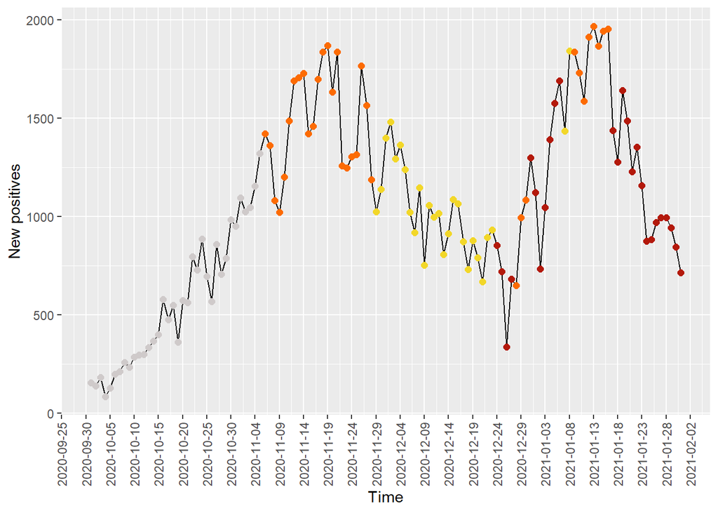

#### Perform some explanatory analysis for your data.

- See how response variable changes wrt explanatory variables provided.

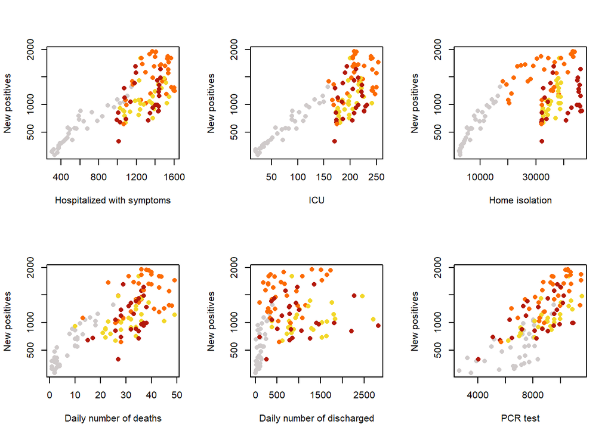

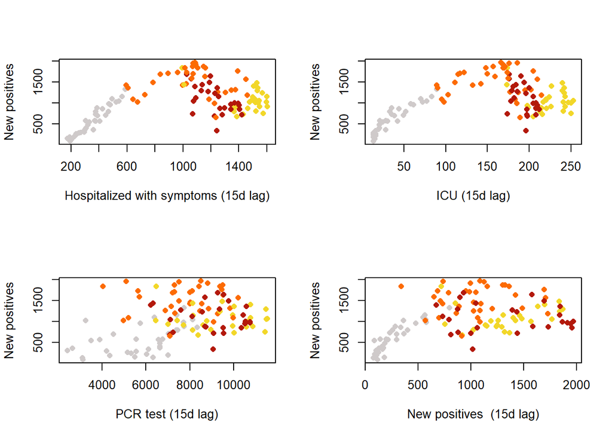

- See how response variable changes wrt covariates considered.

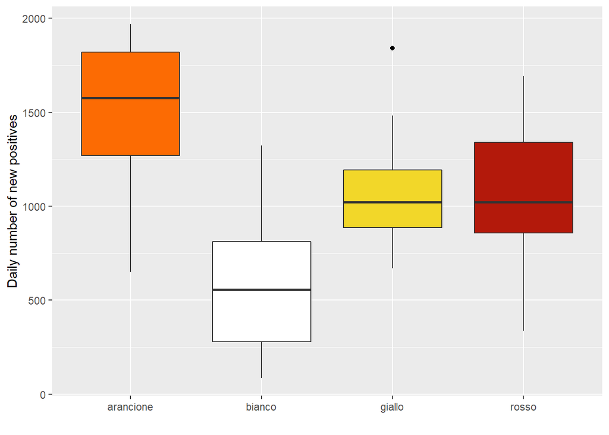

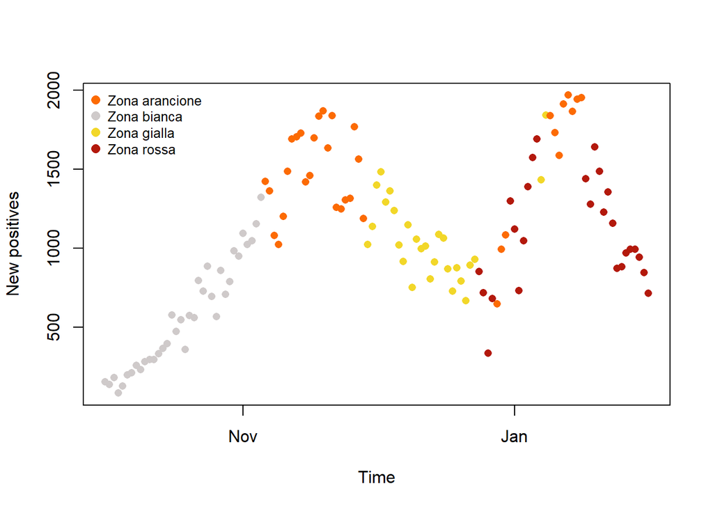

#### Quality of the data

Check for missing values in the data frame

```
##                             na_count
## data                               0
## ricoverati_con_sintomi             0
## terapia_intensiva                  0
## totale_ospedalizzati               0
## isolamento_domiciliare             0
## totale_positivi                    0
## variazione_totale_positivi         0
## nuovi_positivi                     0
## dimessi_guariti                    0
## deceduti                           0
## totale_casi                        0
## tamponi                            0
## casi_testati                       0
## ingressi_terapia_intensiva        63
## tamponi_test_molecolare            0
## color                              0
## nuovi_tamponi_pcr                  0
## nuovi_decessi                      0
## nuovi_dimessi                      0
## terapia_intensiva_prev             0
## ricoverati_con_sintomi_prev        0
## nuovi_tamponi_pcr_prev             0
## nuovi_positivi_prev                0
## color_prev                         0
## var_station                        0
## var_workplace                      0
## var_retail                         0
## var_station_prev                   0
## var_workplace_prev                 0
## var_retail_prev                    0
```

### Correlations

- Understand how each potential predictor relates to the outcome but also to every other predictor.

We observe the following variables: - number of hospedalized with symptoms - number of ICU - number of deaths - number of swabs

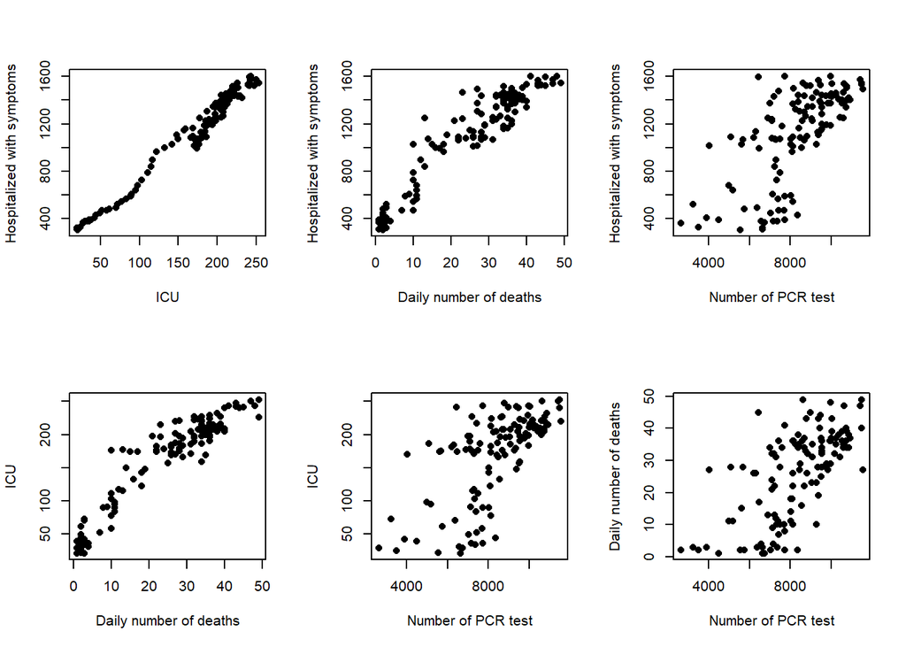

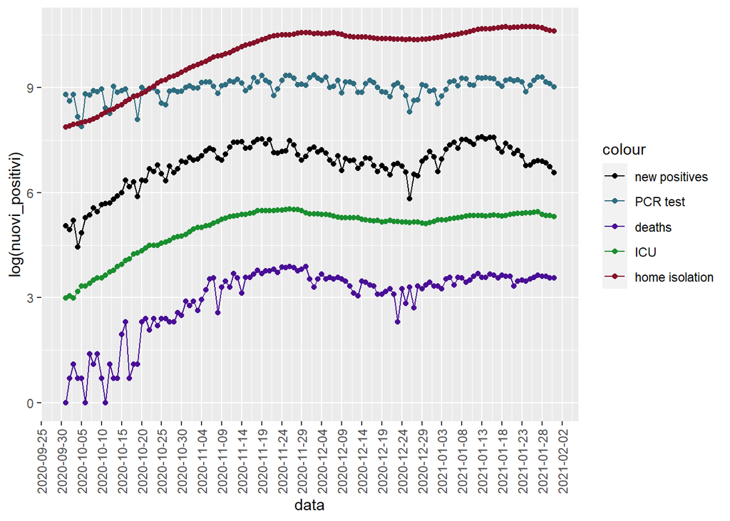

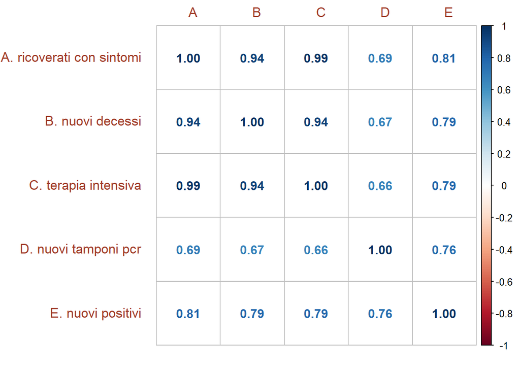

## Building models

Then we start exploring the previous correlation, since the number of swabs carried out is one of the main factor which determines the number of new positives. Indeed, the number of positives is strictly contained in the interval [0, n. of swabs].

```
##
## Call:
## lm(formula = nuovi_positivi ~ nuovi_tamponi_pcr, data = df)
##
## Residuals:
##     Min      1Q  Median      3Q     Max
## -719.81 -226.97    6.12  243.61  601.27
##
## Coefficients:
##                     Estimate Std. Error t value Pr(>|t|)
## (Intercept)       -587.30560  130.39671  -4.504 1.55e-05 ***
## nuovi_tamponi_pcr    0.19678    0.01531  12.857  < 2e-16 ***
## ---
## Signif. codes:  0 '***' 0.001 '**' 0.01 '*' 0.05 '.' 0.1 ' ' 1
##
## Residual standard error: 315.9 on 121 degrees of freedom
## Multiple R-squared:  0.5774, Adjusted R-squared:  0.5739
## F-statistic: 165.3 on 1 and 121 DF,  p-value: < 2.2e-16
```

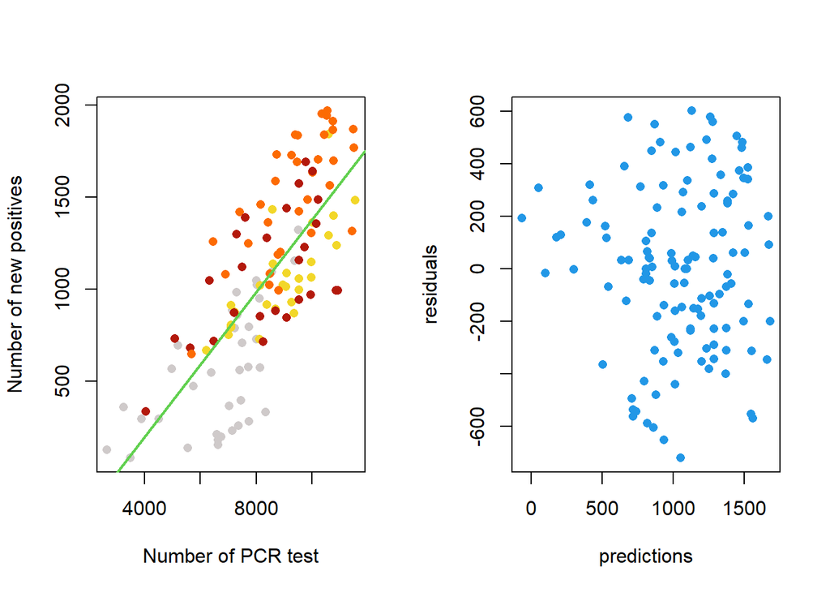

We can observe that the residuals tend to grow for increasing values of our response variable, which corresponds to the days in which there are some restrictions. A second model which accounts for the presence or absence of restrictions:

```
##
## Call:
## lm(formula = nuovi_positivi ~ nuovi_tamponi_pcr + color, data = df)
##
## Residuals:
##     Min      1Q  Median      3Q     Max
## -486.56 -162.35   -0.67  169.46  551.44
##
## Coefficients:
##                     Estimate Std. Error t value Pr(>|t|)
## (Intercept)        244.32436  139.31847   1.754   0.0821 .
## nuovi_tamponi_pcr    0.13638    0.01421   9.596  < 2e-16 ***
## colorbianco       -606.74474   68.79796  -8.819 1.22e-14 ***
## colorgiallo       -397.62040   63.20571  -6.291 5.55e-09 ***
## colorrosso        -305.80477   64.95710  -4.708 6.88e-06 ***
## ---
## Signif. codes:  0 '***' 0.001 '**' 0.01 '*' 0.05 '.' 0.1 ' ' 1
##
## Residual standard error: 244.2 on 118 degrees of freedom
## Multiple R-squared:  0.7539, Adjusted R-squared:  0.7455
## F-statistic: 90.35 on 4 and 118 DF,  p-value: < 2.2e-16
```

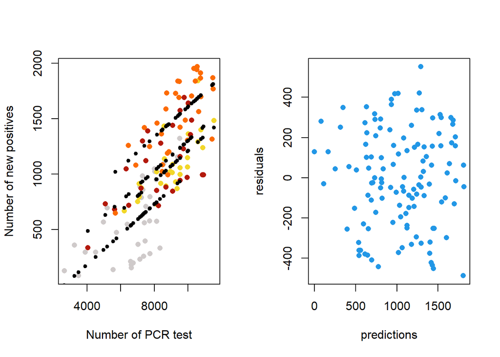

Now we order and see how the residuals change wrt to time, or the date we are considering:

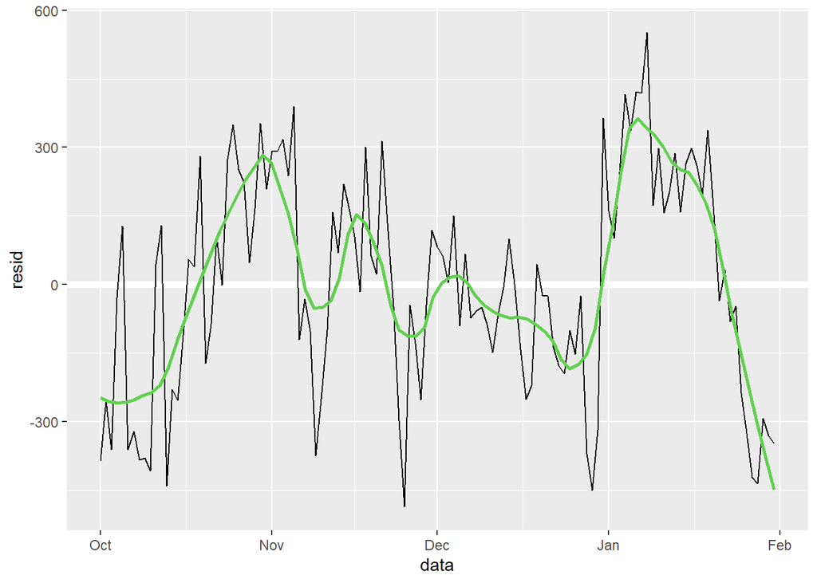

## Building models

We start building our model looking at the relationship between our response variable and its highest correlated predictor (which is given by people hospitalized with symptoms, maybe because the highest the number of people hospitalized, the higher the contagiousness and as a consequence the higher the number of new positives).

### Linear models

```
##
## Call:
## glm(formula = nuovi_positivi ~ ricoverati_con_sintomi, family = "gaussian",
##     data = df)
##
## Deviance Residuals:
##     Min       1Q   Median       3Q      Max
## -613.48  -203.60   -32.51   172.74   660.66
##
## Coefficients:
##                         Estimate Std. Error t value Pr(>|t|)
## (Intercept)            -65.98155   78.67169  -0.839    0.403
## ricoverati_con_sintomi   1.00243    0.06681  15.005   <2e-16 ***
## ---
## Signif. codes:  0 '***' 0.001 '**' 0.01 '*' 0.05 '.' 0.1 ' ' 1
##
## (Dispersion parameter for gaussian family taken to be 82556.22)
##
##     Null deviance: 28577350  on 122  degrees of freedom
## Residual deviance:  9989302  on 121  degrees of freedom
## AIC: 1745.6
##
## Number of Fisher Scoring iterations: 2
```

```
##
## Call:
## glm(formula = nuovi_positivi ~ ricoverati_con_sintomi + color,
##     family = "gaussian", data = df)
##
## Deviance Residuals:
##     Min       1Q   Median       3Q      Max
## -526.53  -141.60   -11.68   141.83   814.03
##
## Coefficients:
##                         Estimate Std. Error t value Pr(>|t|)
## (Intercept)              81.7438   173.1061   0.472    0.638
## ricoverati_con_sintomi    1.0289     0.1199   8.585 4.31e-14 ***
## colorbianco            -129.1461   114.0665  -1.132    0.260
## colorgiallo            -335.8289    67.2963  -4.990 2.10e-06 ***
## colorrosso             -310.7610    68.0731  -4.565 1.23e-05 ***
## ---
## Signif. codes:  0 '***' 0.001 '**' 0.01 '*' 0.05 '.' 0.1 ' ' 1
##
## (Dispersion parameter for gaussian family taken to be 65325.2)
##
##     Null deviance: 28577350  on 122  degrees of freedom
## Residual deviance:  7708374  on 118  degrees of freedom
## AIC: 1719.7
##
## Number of Fisher Scoring iterations: 2
```

```
##
## Call:
## glm(formula = nuovi_positivi ~ ricoverati_con_sintomi * color,
##     family = "gaussian", data = df)
##
## Deviance Residuals:
##     Min       1Q   Median       3Q      Max
## -601.41  -146.32   -15.46   140.34   807.22
##
## Coefficients:
##                                      Estimate Std. Error t value Pr(>|t|)
## (Intercept)                         395.73880  391.95759   1.010  0.31478
## ricoverati_con_sintomi                0.80420    0.27880   2.885  0.00468 **
## colorbianco                        -587.72826  406.65205  -1.445  0.15110
## colorgiallo                        -412.50003  563.44828  -0.732  0.46560
## colorrosso                         -209.92754  541.91381  -0.387  0.69919
## ricoverati_con_sintomi:colorbianco    0.46828    0.32547   1.439  0.15293
## ricoverati_con_sintomi:colorgiallo    0.03973    0.41934   0.095  0.92469
## ricoverati_con_sintomi:colorrosso    -0.09956    0.40224  -0.248  0.80494
## ---
## Signif. codes:  0 '***' 0.001 '**' 0.01 '*' 0.05 '.' 0.1 ' ' 1
##
## (Dispersion parameter for gaussian family taken to be 64584.9)
##
##     Null deviance: 28577350  on 122  degrees of freedom
## Residual deviance:  7427264  on 115  degrees of freedom
## AIC: 1721.1
##
## Number of Fisher Scoring iterations: 2
```

```
##
## Call:
## glm(formula = nuovi_positivi ~ ricoverati_con_sintomi + color +
##     data, family = "gaussian", data = df)
##
## Deviance Residuals:
##     Min       1Q   Median       3Q      Max
## -665.46  -116.37   -24.21   148.99   728.35
##
## Coefficients:
##                          Estimate Std. Error t value Pr(>|t|)
## (Intercept)            -89944.142  25358.648  -3.547 0.000562 ***
## ricoverati_con_sintomi      0.961      0.116   8.287 2.20e-13 ***
## colorbianco                41.557    118.988   0.349 0.727526
## colorgiallo              -387.389     65.835  -5.884 3.89e-08 ***
## colorrosso               -516.502     87.049  -5.933 3.09e-08 ***
## data                        4.845      1.365   3.550 0.000556 ***
## ---
## Signif. codes:  0 '***' 0.001 '**' 0.01 '*' 0.05 '.' 0.1 ' ' 1
##
## (Dispersion parameter for gaussian family taken to be 59476.46)
##
##     Null deviance: 28577350  on 122  degrees of freedom
## Residual deviance:  6958746  on 117  degrees of freedom
## AIC: 1709.1
##
## Number of Fisher Scoring iterations: 2
```

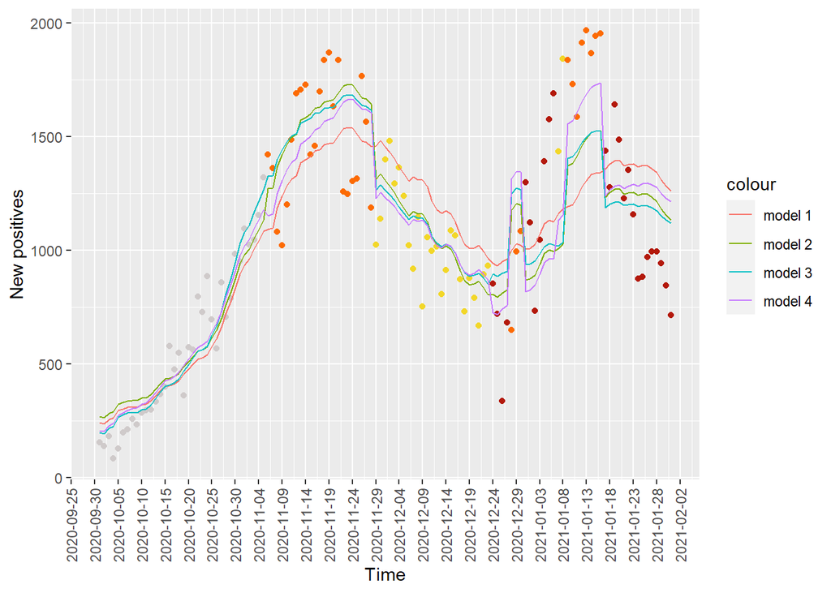

```
##         df      AIC
## lm_mod1  3 1745.554
## lm_mod2  6 1719.672
## lm_mod3  9 1721.102
## lm_mod4  7 1709.088
```

### Generalized linear models

```
##
## Call:
## glm(formula = nuovi_positivi ~ ricoverati_con_sintomi + color,
##     family = poisson(link = "log"), data = df)
##
## Deviance Residuals:
##      Min        1Q    Median        3Q       Max
## -19.1007   -6.7887    0.0836    4.8164   23.5829
##
## Coefficients:
##                          Estimate Std. Error z value Pr(>|z|)
## (Intercept)             5.720e+00  2.268e-02 252.259  < 2e-16 ***
## ricoverati_con_sintomi  1.138e-03  1.563e-05  72.848  < 2e-16 ***
## colorbianco            -1.062e-01  1.435e-02  -7.403 1.33e-13 ***
## colorgiallo            -2.248e-01  7.565e-03 -29.722  < 2e-16 ***
## colorrosso             -2.036e-01  7.604e-03 -26.778  < 2e-16 ***
## ---
## Signif. codes:  0 '***' 0.001 '**' 0.01 '*' 0.05 '.' 0.1 ' ' 1
##
## (Dispersion parameter for poisson family taken to be 1)
##
##     Null deviance: 30598.5  on 122  degrees of freedom
## Residual deviance:  9192.5  on 118  degrees of freedom
## AIC: 10265
##
## Number of Fisher Scoring iterations: 4
```

```
##
## Call:
## glm(formula = nuovi_positivi ~ ricoverati_con_sintomi + color +
##     data, family = poisson(link = "log"), data = df)
##
## Deviance Residuals:
##      Min        1Q    Median        3Q       Max
## -17.5930   -5.9717    0.4208    4.6499   22.9880
##
## Coefficients:
##                          Estimate Std. Error z value Pr(>|z|)
## (Intercept)            -9.044e+01  2.832e+00 -31.937  < 2e-16 ***
## ricoverati_con_sintomi  1.143e-03  1.566e-05  72.944  < 2e-16 ***
## colorbianco             1.206e-01  1.577e-02   7.647 2.06e-14 ***
## colorgiallo            -2.650e-01  7.620e-03 -34.779  < 2e-16 ***
## colorrosso             -4.266e-01  9.861e-03 -43.257  < 2e-16 ***
## data                    5.170e-03  1.522e-04  33.966  < 2e-16 ***
## ---
## Signif. codes:  0 '***' 0.001 '**' 0.01 '*' 0.05 '.' 0.1 ' ' 1
##
## (Dispersion parameter for poisson family taken to be 1)
##
##     Null deviance: 30598.5  on 122  degrees of freedom
## Residual deviance:  8064.5  on 117  degrees of freedom
## AIC: 9138.6
##
## Number of Fisher Scoring iterations: 4
```

```
##
## Call:
## glm(formula = nuovi_positivi ~ ricoverati_con_sintomi * color +
##     data, family = poisson(link = "log"), data = df)
##
## Deviance Residuals:
##      Min        1Q    Median        3Q       Max
## -21.5420   -6.1691   -0.9382    4.6799   19.5840
##
## Coefficients:
##                                      Estimate Std. Error z value Pr(>|z|)
## (Intercept)                        -7.843e+01  3.329e+00 -23.559  < 2e-16 ***
## ricoverati_con_sintomi              8.248e-04  3.152e-05  26.171  < 2e-16 ***
## colorbianco                        -8.185e-01  5.422e-02 -15.095  < 2e-16 ***
## colorgiallo                        -5.466e-01  6.494e-02  -8.416  < 2e-16 ***
## colorrosso                          1.694e-01  6.733e-02   2.516   0.0119 *
## data                                4.548e-03  1.781e-04  25.543  < 2e-16 ***
## ricoverati_con_sintomi:colorbianco  9.670e-04  4.247e-05  22.768  < 2e-16 ***
## ricoverati_con_sintomi:colorgiallo  1.923e-04  4.804e-05   4.004 6.24e-05 ***
## ricoverati_con_sintomi:colorrosso  -4.609e-04  5.194e-05  -8.874  < 2e-16 ***
## ---
## Signif. codes:  0 '***' 0.001 '**' 0.01 '*' 0.05 '.' 0.1 ' ' 1
##
## (Dispersion parameter for poisson family taken to be 1)
##
##     Null deviance: 30598.5  on 122  degrees of freedom
## Residual deviance:  6824.8  on 114  degrees of freedom
## AIC: 7905
##
## Number of Fisher Scoring iterations: 4
```

```
##
## Call:
## glm(formula = nuovi_positivi ~ (ricoverati_con_sintomi + terapia_intensiva) *
##     color + data, family = poisson(link = "log"), data = df)
##
## Deviance Residuals:
##      Min        1Q    Median        3Q       Max
## -22.3450   -4.3492    0.3202    3.7574   21.6481
##
## Coefficients:
##                                      Estimate Std. Error z value Pr(>|z|)
## (Intercept)                        -8.953e+01  3.597e+00 -24.889  < 2e-16 ***
## ricoverati_con_sintomi              1.649e-03  9.559e-05  17.254  < 2e-16 ***
## terapia_intensiva                  -4.888e-03  5.299e-04  -9.225  < 2e-16 ***
## colorbianco                        -3.302e-01  5.774e-02  -5.719 1.07e-08 ***
## colorgiallo                        -6.639e-01  8.869e-02  -7.485 7.14e-14 ***
## colorrosso                          1.496e+00  8.909e-02  16.795  < 2e-16 ***
## data                                5.139e-03  1.923e-04  26.725  < 2e-16 ***
## ricoverati_con_sintomi:colorbianco -3.679e-03  1.640e-04 -22.441  < 2e-16 ***
## ricoverati_con_sintomi:colorgiallo -9.323e-04  1.454e-04  -6.412 1.43e-10 ***
## ricoverati_con_sintomi:colorrosso   9.263e-04  1.437e-04   6.445 1.16e-10 ***
## terapia_intensiva:colorbianco       3.006e-02  1.017e-03  29.547  < 2e-16 ***
## terapia_intensiva:colorgiallo       7.940e-03  1.122e-03   7.076 1.48e-12 ***
## terapia_intensiva:colorrosso       -1.536e-02  1.030e-03 -14.911  < 2e-16 ***
## ---
## Signif. codes:  0 '***' 0.001 '**' 0.01 '*' 0.05 '.' 0.1 ' ' 1
##
## (Dispersion parameter for poisson family taken to be 1)
##
##     Null deviance: 30598.5  on 122  degrees of freedom
## Residual deviance:  5395.1  on 110  degrees of freedom
## AIC: 6483.2
##
## Number of Fisher Scoring iterations: 4
```

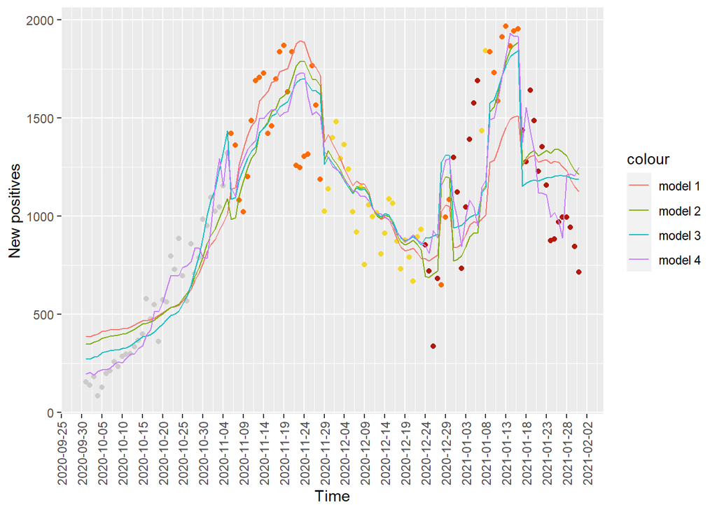

```
##          df       AIC
## glm_mod1  5 10264.652
## glm_mod2  6  9138.623
## glm_mod3  9  7904.989
## glm_mod4 13  6483.224
```

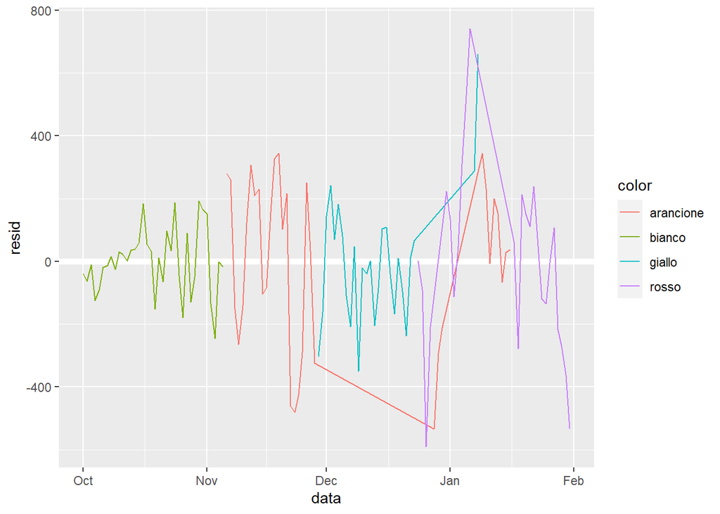

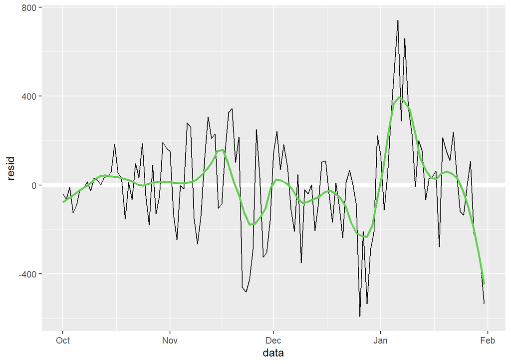

```
##
## Call:
## glm(formula = nuovi_positivi ~ ricoverati_con_sintomi * color +
##     data + ricoverati_con_sintomi_prev + nuovi_tamponi_pcr, family = poisson(link = "log"),
##     data = df)
##
## Deviance Residuals:
##      Min        1Q    Median        3Q       Max
## -14.0958   -3.7594   -0.1307    3.3600   14.7200
##
## Coefficients:
##                                      Estimate Std. Error z value Pr(>|z|)
## (Intercept)                        -9.394e+01  3.484e+00 -26.961  < 2e-16 ***
## ricoverati_con_sintomi              1.245e-03  4.069e-05  30.596  < 2e-16 ***
## colorbianco                        -4.780e-01  5.726e-02  -8.347  < 2e-16 ***
## colorgiallo                         4.318e-01  7.032e-02   6.140 8.23e-10 ***
## colorrosso                          1.667e+00  7.482e-02  22.277  < 2e-16 ***
## data                                5.347e-03  1.866e-04  28.656  < 2e-16 ***
## ricoverati_con_sintomi_prev        -7.882e-04  1.996e-05 -39.499  < 2e-16 ***
## nuovi_tamponi_pcr                   9.493e-05  2.448e-06  38.778  < 2e-16 ***
## ricoverati_con_sintomi:colorbianco  5.040e-04  4.570e-05  11.028  < 2e-16 ***
## ricoverati_con_sintomi:colorgiallo -2.666e-04  5.031e-05  -5.298 1.17e-07 ***
## ricoverati_con_sintomi:colorrosso  -1.441e-03  5.618e-05 -25.648  < 2e-16 ***
## ---
## Signif. codes:  0 '***' 0.001 '**' 0.01 '*' 0.05 '.' 0.1 ' ' 1
##
## (Dispersion parameter for poisson family taken to be 1)
##
##     Null deviance: 30598.5  on 122  degrees of freedom
## Residual deviance:  3414.1  on 112  degrees of freedom
## AIC: 4498.3
##
## Number of Fisher Scoring iterations: 4
```

```
##
## Call:
## glm(formula = nuovi_positivi ~ (ricoverati_con_sintomi + terapia_intensiva) *
##     color + data + ricoverati_con_sintomi_prev + nuovi_tamponi_pcr,
##     family = poisson(link = "log"), data = df)
##
## Deviance Residuals:
##      Min        1Q    Median        3Q       Max
## -14.1441   -2.1669    0.1367    2.2793    8.6980
##
## Coefficients:
##                                      Estimate Std. Error z value Pr(>|z|)
## (Intercept)                        -7.875e+01  3.652e+00 -21.566  < 2e-16 ***
## ricoverati_con_sintomi             -1.120e-05  1.046e-04  -0.107    0.915
## terapia_intensiva                   8.112e-03  6.395e-04  12.684  < 2e-16 ***
## colorbianco                        -3.139e-01  6.043e-02  -5.194 2.05e-07 ***
## colorgiallo                         8.485e-01  1.010e-01   8.397  < 2e-16 ***
## colorrosso                          2.508e+00  9.260e-02  27.084  < 2e-16 ***
## data                                4.540e-03  1.954e-04  23.239  < 2e-16 ***
## ricoverati_con_sintomi_prev        -9.555e-04  2.489e-05 -38.396  < 2e-16 ***
## nuovi_tamponi_pcr                   9.709e-05  2.480e-06  39.145  < 2e-16 ***
## ricoverati_con_sintomi:colorbianco -2.512e-03  1.694e-04 -14.831  < 2e-16 ***
## ricoverati_con_sintomi:colorgiallo  1.702e-03  1.694e-04  10.048  < 2e-16 ***
## ricoverati_con_sintomi:colorrosso   1.621e-03  1.485e-04  10.917  < 2e-16 ***
## terapia_intensiva:colorbianco       2.078e-02  1.062e-03  19.569  < 2e-16 ***
## terapia_intensiva:colorgiallo      -1.457e-02  1.330e-03 -10.959  < 2e-16 ***
## terapia_intensiva:colorrosso       -2.361e-02  1.053e-03 -22.421  < 2e-16 ***
## ---
## Signif. codes:  0 '***' 0.001 '**' 0.01 '*' 0.05 '.' 0.1 ' ' 1
##
## (Dispersion parameter for poisson family taken to be 1)
##
##     Null deviance: 30598.5  on 122  degrees of freedom
## Residual deviance:  1839.7  on 108  degrees of freedom
## AIC: 2931.9
##
## Number of Fisher Scoring iterations: 4
```

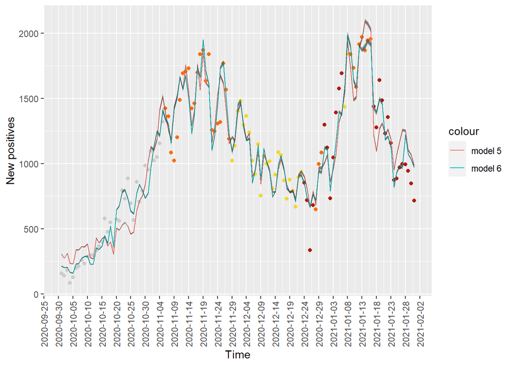

```
##          df      AIC
## glm_mod5 11 4498.256
## glm_mod6 15 2931.907
```

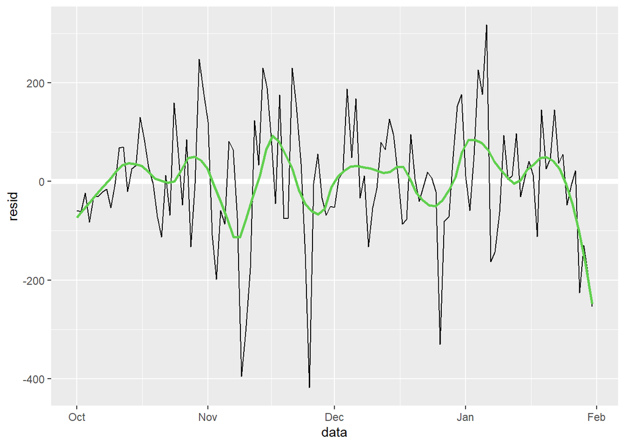

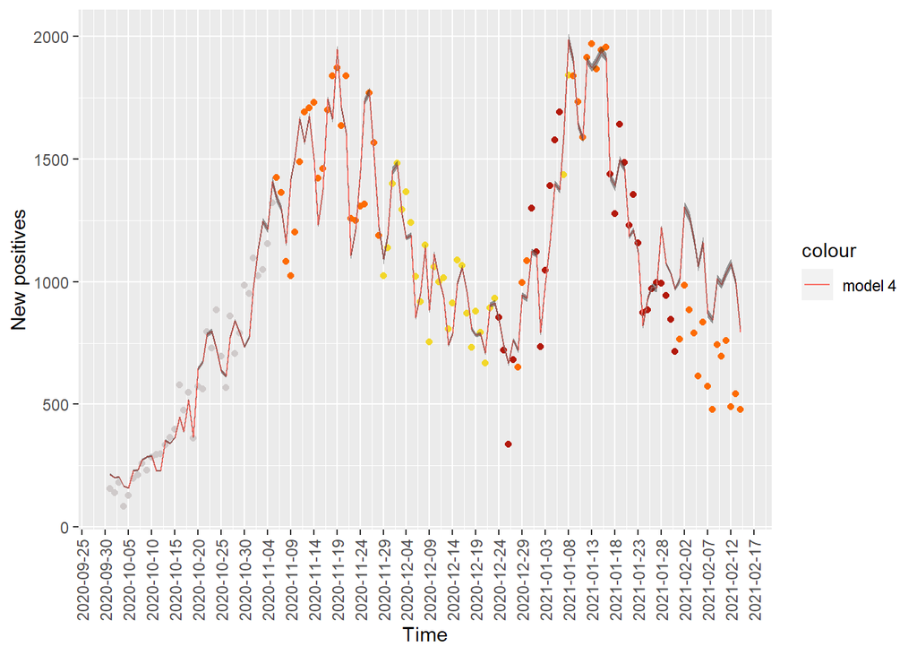

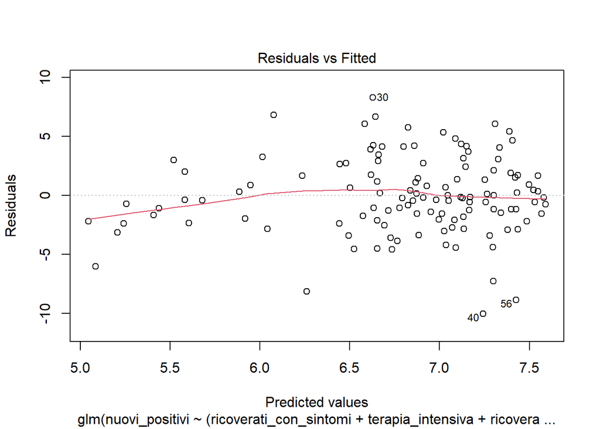

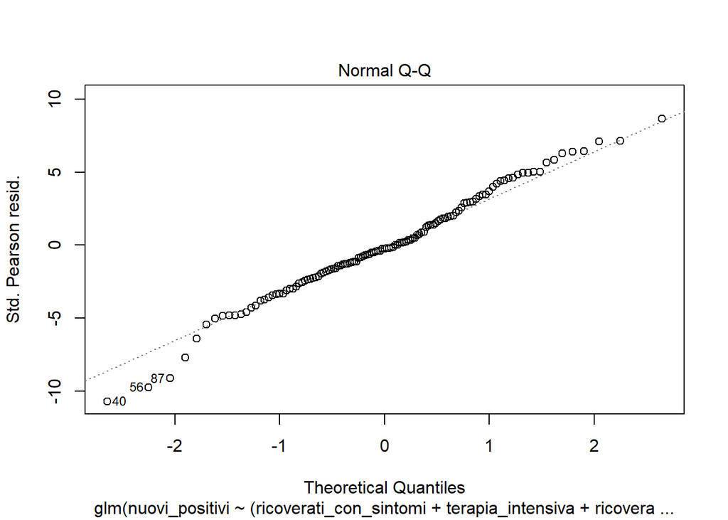

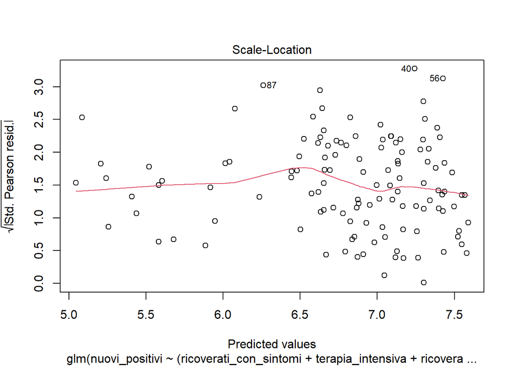

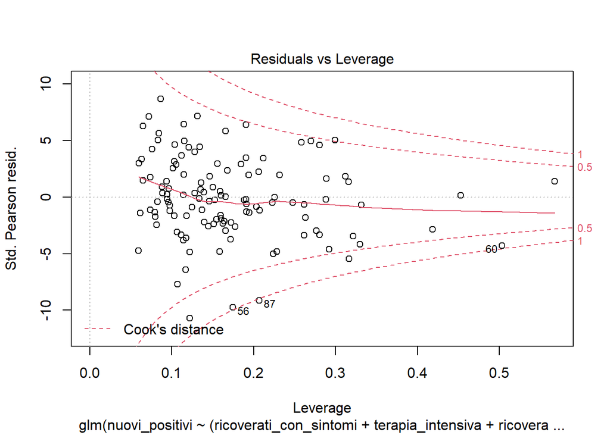

```
##
## Call:
## glm(formula = nuovi_positivi ~ (ricoverati_con_sintomi + terapia_intensiva +
##     ricoverati_con_sintomi_prev + nuovi_tamponi_pcr) * color +
##     data, family = poisson(link = "log"), data = df)
##
## Deviance Residuals:
##      Min        1Q    Median        3Q       Max
## -10.5587   -2.0783   -0.2144    1.9172    7.9201
##
## Coefficients:
##                                           Estimate Std. Error z value Pr(>|z|)
## (Intercept)                             -9.581e+01  4.232e+00 -22.642  < 2e-16
## ricoverati_con_sintomi                   2.675e-04  1.092e-04   2.449   0.0143
## terapia_intensiva                        6.884e-03  7.594e-04   9.066  < 2e-16
## ricoverati_con_sintomi_prev             -9.026e-04  4.083e-05 -22.105  < 2e-16
## nuovi_tamponi_pcr                        7.424e-05  3.827e-06  19.399  < 2e-16
## colorbianco                             -6.976e-01  1.032e-01  -6.761 1.37e-11
## colorgiallo                              1.914e-01  1.219e-01   1.570   0.1165
## colorrosso                               3.075e+00  9.744e-02  31.556  < 2e-16
## data                                     5.459e-03  2.267e-04  24.080  < 2e-16
## ricoverati_con_sintomi:colorbianco      -2.901e-03  1.788e-04 -16.223  < 2e-16
## ricoverati_con_sintomi:colorgiallo       9.063e-04  1.775e-04   5.105 3.30e-07
## ricoverati_con_sintomi:colorrosso        6.406e-04  1.578e-04   4.060 4.92e-05
## terapia_intensiva:colorbianco            1.345e-02  1.762e-03   7.631 2.34e-14
## terapia_intensiva:colorgiallo           -9.673e-03  1.363e-03  -7.097 1.27e-12
## terapia_intensiva:colorrosso            -1.715e-02  1.248e-03 -13.739  < 2e-16
## ricoverati_con_sintomi_prev:colorbianco  3.434e-03  5.718e-04   6.006 1.91e-09
## ricoverati_con_sintomi_prev:colorgiallo  2.891e-04  6.312e-05   4.581 4.63e-06
## ricoverati_con_sintomi_prev:colorrosso  -1.049e-03  7.071e-05 -14.828  < 2e-16
## nuovi_tamponi_pcr:colorbianco            4.632e-06  7.457e-06   0.621   0.5345
## nuovi_tamponi_pcr:colorgiallo            2.904e-05  6.487e-06   4.476 7.60e-06
## nuovi_tamponi_pcr:colorrosso             7.127e-05  6.603e-06  10.794  < 2e-16
##
## (Intercept)                             ***
## ricoverati_con_sintomi                  *
## terapia_intensiva                       ***
## ricoverati_con_sintomi_prev             ***
## nuovi_tamponi_pcr                       ***
## colorbianco                             ***
```

[output cut: 10 more lines]

```
## ricoverati_con_sintomi_prev:colorgiallo ***
## ricoverati_con_sintomi_prev:colorrosso  ***
## nuovi_tamponi_pcr:colorbianco
## nuovi_tamponi_pcr:colorgiallo           ***
## nuovi_tamponi_pcr:colorrosso            ***
## ---
## Signif. codes:  0 '***' 0.001 '**' 0.01 '*' 0.05 '.' 0.1 ' ' 1
##
## (Dispersion parameter for poisson family taken to be 1)
##
##     Null deviance: 30598.5  on 122  degrees of freedom
## Residual deviance:  1324.2  on 102  degrees of freedom
## AIC: 2428.4
##
## Number of Fisher Scoring iterations: 4
```

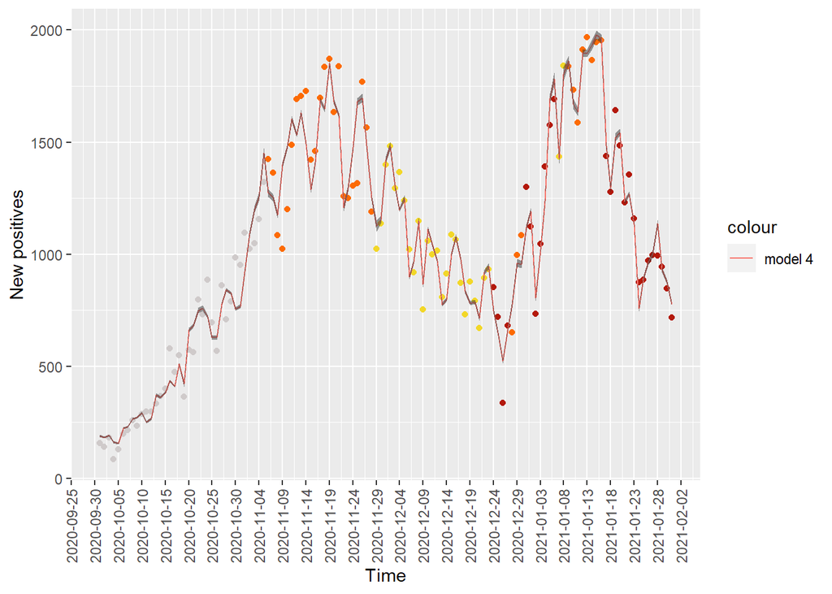

```
##          df       AIC
## glm_mod7 21  2428.391
## glm_mod6 15  2931.907
## glm_mod5 11  4498.256
## glm_mod4 13  6483.224
## glm_mod3  9  7904.989
## glm_mod2  6  9138.623
## glm_mod1  5 10264.652
```

```
## [1] 0.01390998
```

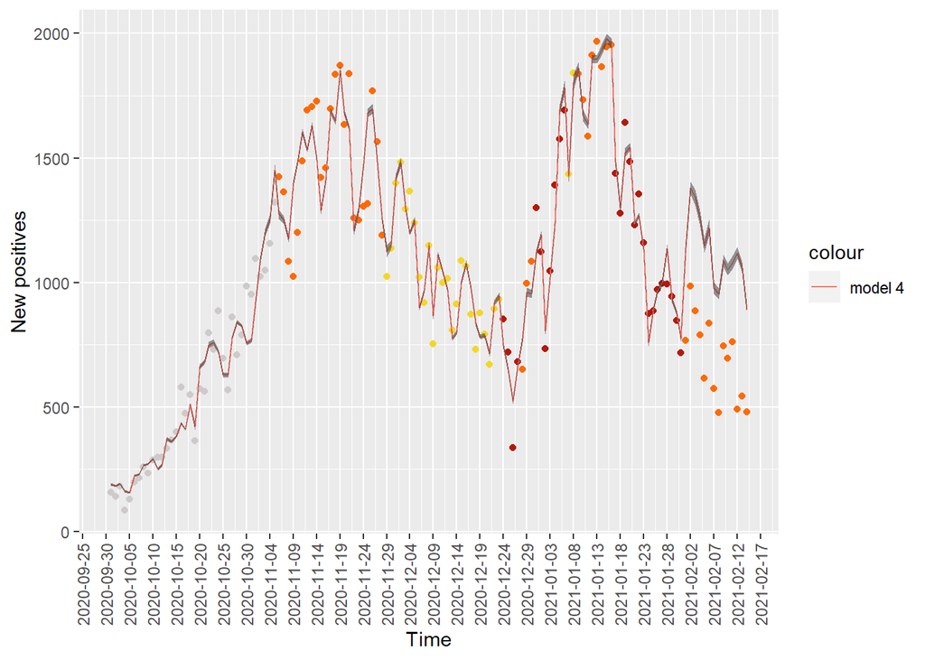